# PartB

Ulita Gilbert

05/03/2021

# 1 Data Dictionary

For the purposes of this EDA, the following variables and definitions are important.

The population in this dataset is the incoming cohort of students in Fall each year. These students are first time degree or certificate seekers and have no prior tertiary education.

**Fall2019** refers to the incoming freshman cohort in Fall2019. This is also term year 2020.  
**Fall2020** refers to the incoming freshman cohort in Fall2020. This is term year 2021.

**Variables of Interest:**  
**hours_earned:** refers to credits the student has earned in their first Fall semester ( this can include credits earned in Summer school second session- Summer 1).  
**hours_attempted:** refers to credits the student has attempted in their first Fall semester ( this can include credits attempted in Summerschool second session - Summer 1).

**full_part:** is the student full-time (FT) or part-time (PT)

**major:** degree programme student is registered for or certificate&LR ( letter of recommendation.) All certificates and letters of recommendations have been grouped together.

**hours_pass_rate:** Ratio of hours_earned/hours_attempted

# 2 Import Data

```r
#import data for Fall 2016 to Fall 2020
# set directory
setwd('/Users/ulita/Documents/CAPSTONE205/Capstone/Capstone_Data/Raw_Data')

df_2019<-read_xlsx("FTEIC F19.xlsx")
df_2020<-read_xlsx("FTEIC F20.xlsx")
```

# 3 Create Dataframe

```r
 #create dataframe to compare credits in Fall 2019 and Fall 2020 :    df_credits
df_credits<- bind_rows(df_2019,df_2020)

head(df_credits)
```

```
## # A tibble: 6 x 50
##   `U-Number` Sex   IPEDS_RACE_DESC `Age at Start` HIGH_SCHOOL FULL_PART CITY
##        <dbl> <chr> <chr>           <chr>          <chr>       <chr>     <chr>
## 1   20190001 F     Hispanic        18 - 20        Out of Sta… PT        Gait…
## 2   20190002 M     Hispanic        18 - 20        Walter Joh… FT        Rock…
## 3   20190003 F     Multi-Race      18 - 20        Wheaton Hi… PT        Gait…
## 4   20190004 M     Asian           18 - 20        Thomas Spr… PT        Gait…
## 5   20190005 M     Hispanic        18 - 20        FOREIGN / … FT        Chev…
## 6   20190006 F     Hispanic        18 - 20        Springbroo… FT        Silv…
## # … with 43 more variables: STAT_CODE <chr>, ZIP <dbl>, PELL_GRANT <chr>,
## #   CAMP_CODE <chr>, Major <chr>, HOURS_ATTEMPTED <chr>, HOURS_EARNED <chr>,
## #   MC_GPA <dbl>, PASS_ENGL <chr>, PASS_MATH <chr>, term_year <chr>,
## #   TERM_YEAR1_10 <chr>, TERM_YEAR1_20 <chr>, TERM_YEAR1_24 <chr>,
## #   TERM_YEAR1_25 <chr>, TERM_YEAR1_30 <chr>, TERM_YEAR1_40 <chr>,
## #   TERM_YEAR2_10 <chr>, TERM_YEAR2_20 <chr>, TERM_YEAR2_24 <chr>,
## #   TERM_YEAR2_25 <chr>, TERM_YEAR2_30 <chr>, TERM_YEAR2_40 <chr>,
## #   TERM_YEAR3_10 <chr>, TERM_YEAR3_20 <chr>, TERM_YEAR3_24 <chr>,
## #   TERM_YEAR3_25 <chr>, TERM_YEAR3_30 <chr>, TERM_YEAR3_40 <chr>,
## #   TERM_YEAR4_10 <chr>, TERM_YEAR4_20 <chr>, TERM_YEAR4_24 <chr>,
## #   TERM_YEAR4_25 <chr>, TERM_YEAR4_30 <chr>, TERM_YEAR4_40 <chr>,
## #   TERM_YEAR5_10 <chr>, TERM_YEAR5_20 <chr>, TERM_YEAR5_24 <chr>,
## #   TERM_YEAR5_25 <chr>, TERM_YEAR5_30 <chr>, first_grad_date <lgl>,
## #   first_degree <lgl>, TERM_YEAR5_40 <chr>
```

# 4 Data Wrangling

## 4.1 Select Columns of Interest & Format Names

```r
#clean names using janitor package
df_credits<-df_credits %>%
              clean_names()

#drop columns not interested in

df_credits<-df_credits %>%
             select(c(1:18))

# rename columns to make it user friendly
df_credits<-df_credits %>%
            rename("age"= "age_at_start", "race"= "ipeds_race_desc")
```

## 4.2 Statistical Summary of Data

```r
# summary statistics of dataframing using function skimr creates a table of summary statistics of all variables in the dataframe
skim(df_credits)
```

Data summary

| Name | df_credits |
| --- | --- |
| Number of rows | 7519 |
| Number of columns | 18 |
| _______________________ |  |
| Column type frequency: |  |
| character | 15 |
| numeric | 3 |
| ________________________ |  |
| Group variables | None |

**Variable type: character**

| skim_variable | n_missing | complete_rate | min | max | empty | n_unique | whitespace |
| --- | --- | --- | --- | --- | --- | --- | --- |
| sex | 0 | 1.00 | 1 | 1 | 0 | 4 | 0 |
| race | 0 | 1.00 | 5 | 22 | 0 | 9 | 0 |
| age | 0 | 1.00 | 4 | 7 | 0 | 5 | 0 |
| high_school | 0 | 1.00 | 7 | 30 | 0 | 172 | 0 |
| full_part | 0 | 1.00 | 2 | 2 | 0 | 2 | 0 |
| city | 21 | 1.00 | 5 | 19 | 0 | 132 | 0 |
| stat_code | 21 | 1.00 | 2 | 2 | 0 | 16 | 0 |
| pell_grant | 0 | 1.00 | 1 | 1 | 0 | 2 | 0 |
| camp_code | 154 | 0.98 | 1 | 1 | 0 | 6 | 0 |
| major | 33 | 1.00 | 1 | 61 | 0 | 35 | 0 |
| hours_attempted | 87 | 0.99 | 2 | 4 | 0 | 55 | 0 |
| hours_earned | 87 | 0.99 | 2 | 4 | 0 | 56 | 0 |
| pass_engl | 0 | 1.00 | 1 | 1 | 0 | 2 | 0 |
| pass_math | 0 | 1.00 | 1 | 1 | 0 | 2 | 0 |
| term_year | 0 | 1.00 | 4 | 4 | 0 | 2 | 0 |

**Variable type: numeric**

| skim_variable | n_missing | complete_rate | mean | sd | p0 | p25 | p50 | p75 | p100 | hist |
| --- | --- | --- | --- | --- | --- | --- | --- | --- | --- | --- |
| u_number | 0 | 1.00 | 20196656.07 | 5028.73 | 20190001 | 20191880.5 | 20193760.0 | 20201708.5 | 20203588 | ▇▃▁▂▇ |
| zip | 21 | 1.00 | 20884.18 | 1518.62 | 1460 | 20853.0 | 20877.0 | 20902.0 | 94025 | ▁▇▁▁▁ |
| mc_gpa | 87 | 0.99 | 2.16 | 1.48 | 0 | 0.5 | 2.5 | 3.5 | 4 | ▆▂▃▅▇ |

There are 18 variables and 7519 rows of data.Need to change the data types for hours_attempted and hours_earned to numeric. u_number should be a charater. Most of the missing values are in camp_code. For the purposes of this exercise, this variable is not important. There are also 87 missing values in hours attempted and hours earned. As these two are the variables of interest and GPA are of interest, I will drop the rows in these variables with missing values.

## 4.3 Change Datatypes

```r
# Change datatypes
df_credits$hours_attempted<- as.integer(df_credits$hours_attempted)
df_credits$hours_earned<- as.integer(df_credits$hours_earned)
df_credits$mc_gpa<- as.double(df_credits$mc_gpa)
df_credits$u_number<- as.character(df_credits$u_number)
df_credits$zip<- as.character(df_credits$zip)

#drop missing values in hours_attempted, hours_earned and mc_gap

df_credits <- df_credits %>%
              drop_na(hours_attempted,hours_earned)
```

Summarise data again

```r
skim(df_credits)
```

Data summary

| Name | df_credits |
| --- | --- |
| Number of rows | 7432 |
| Number of columns | 18 |
| _______________________ |  |
| Column type frequency: |  |
| character | 15 |
| numeric | 3 |
| ________________________ |  |
| Group variables | None |

**Variable type: character**

| skim_variable | n_missing | complete_rate | min | max | empty | n_unique | whitespace |
| --- | --- | --- | --- | --- | --- | --- | --- |
| u_number | 0 | 1.00 | 8 | 8 | 0 | 7432 | 0 |
| sex | 0 | 1.00 | 1 | 1 | 0 | 4 | 0 |
| race | 0 | 1.00 | 5 | 22 | 0 | 9 | 0 |
| age | 0 | 1.00 | 4 | 7 | 0 | 5 | 0 |
| high_school | 0 | 1.00 | 7 | 30 | 0 | 171 | 0 |
| full_part | 0 | 1.00 | 2 | 2 | 0 | 2 | 0 |
| city | 20 | 1.00 | 5 | 19 | 0 | 131 | 0 |
| stat_code | 20 | 1.00 | 2 | 2 | 0 | 16 | 0 |
| zip | 20 | 1.00 | 4 | 5 | 0 | 166 | 0 |
| pell_grant | 0 | 1.00 | 1 | 1 | 0 | 2 | 0 |
| camp_code | 152 | 0.98 | 1 | 1 | 0 | 6 | 0 |
| major | 33 | 1.00 | 1 | 61 | 0 | 35 | 0 |
| pass_engl | 0 | 1.00 | 1 | 1 | 0 | 2 | 0 |
| pass_math | 0 | 1.00 | 1 | 1 | 0 | 2 | 0 |
| term_year | 0 | 1.00 | 4 | 4 | 0 | 2 | 0 |

**Variable type: numeric**

| skim_variable | n_missing | complete_rate | mean | sd | p0 | p25 | p50 | p75 | p100 | hist |
| --- | --- | --- | --- | --- | --- | --- | --- | --- | --- | --- |
| hours_attempted | 0 | 1 | 12.29 | 6.27 | 0 | 9.0 | 12.0 | 15.0 | 54 | ▆▇▁▁▁ |
| hours_earned | 0 | 1 | 7.72 | 7.40 | 0 | 3.0 | 6.0 | 12.0 | 54 | ▇▃▁▁▁ |
| mc_gpa | 0 | 1 | 2.16 | 1.48 | 0 | 0.5 | 2.5 | 3.5 | 4 | ▆▂▃▅▇ |

## 4.4 Missing Values

```r
# Check number of students who attempted 0 credits i.e  hours_attempted =0

df_credits %>% count(hours_attempted==0)
```

```
## # A tibble: 2 x 2
##   `hours_attempted == 0`     n
##   <lgl>                  <int>
## 1 FALSE                   7385
## 2 TRUE                      47
```

47 students attempted zero hours. These 47 observations will be dropped.

```r
# check data for consistency. Hours earned cannot be greater than hours attempted.

df_credits %>% count(hours_attempted<hours_earned)
```

```
## # A tibble: 2 x 2
##   `hours_attempted < hours_earned`     n
##   <lgl>                            <int>
## 1 FALSE                             7427
## 2 TRUE                                 5
```

There are 5 strange datapoints with hours_earned greater than hours_attempted. Drop these 5 data points.

```r
# remove inconsistent data points. Hours earned cannot be bigger than hours attempted

df_credits <- df_credits%>%
              filter(., hours_attempted != 0)

df_credits <- df_credits%>%
              filter(., hours_attempted >= hours_earned)

skim(df_credits)
```

Data summary

| Name | df_credits |
| --- | --- |
| Number of rows | 7380 |
| Number of columns | 18 |
| _______________________ |  |
| Column type frequency: |  |
| character | 15 |
| numeric | 3 |
| ________________________ |  |
| Group variables | None |

**Variable type: character**

| skim_variable | n_missing | complete_rate | min | max | empty | n_unique | whitespace |
| --- | --- | --- | --- | --- | --- | --- | --- |
| u_number | 0 | 1.00 | 8 | 8 | 0 | 7380 | 0 |
| sex | 0 | 1.00 | 1 | 1 | 0 | 4 | 0 |
| race | 0 | 1.00 | 5 | 22 | 0 | 9 | 0 |
| age | 0 | 1.00 | 4 | 7 | 0 | 5 | 0 |
| high_school | 0 | 1.00 | 7 | 30 | 0 | 169 | 0 |
| full_part | 0 | 1.00 | 2 | 2 | 0 | 2 | 0 |
| city | 19 | 1.00 | 5 | 19 | 0 | 130 | 0 |
| stat_code | 19 | 1.00 | 2 | 2 | 0 | 16 | 0 |
| zip | 19 | 1.00 | 4 | 5 | 0 | 164 | 0 |
| pell_grant | 0 | 1.00 | 1 | 1 | 0 | 2 | 0 |
| camp_code | 152 | 0.98 | 1 | 1 | 0 | 6 | 0 |
| major | 33 | 1.00 | 1 | 61 | 0 | 35 | 0 |
| pass_engl | 0 | 1.00 | 1 | 1 | 0 | 2 | 0 |
| pass_math | 0 | 1.00 | 1 | 1 | 0 | 2 | 0 |
| term_year | 0 | 1.00 | 4 | 4 | 0 | 2 | 0 |

**Variable type: numeric**

| skim_variable | n_missing | complete_rate | mean | sd | p0 | p25 | p50 | p75 | p100 | hist |
| --- | --- | --- | --- | --- | --- | --- | --- | --- | --- | --- |
| hours_attempted | 0 | 1 | 12.37 | 6.22 | 1 | 9.00 | 12.0 | 15.0 | 54 | ▆▇▁▁▁ |
| hours_earned | 0 | 1 | 7.76 | 7.40 | 0 | 3.00 | 6.0 | 12.0 | 54 | ▇▃▁▁▁ |
| mc_gpa | 0 | 1 | 2.17 | 1.48 | 0 | 0.62 | 2.5 | 3.5 | 4 | ▆▂▃▅▇ |

There are now 18 variables with 7380 rows

## 4.5 Full time versus Part-time students

```r
# Number of Full time versus Part time student by year

df_credits %>% group_by(term_year, full_part) %>%
  summarise(n=n())
```

```
## # A tibble: 4 x 3
## # Groups:   term_year [2]
##   term_year full_part     n
##   <chr>     <chr>     <int>
## 1 2020      FT         2251
## 2 2020      PT         1606
## 3 2021      FT         2147
## 4 2021      PT         1376
```

In term year 2020( Fall 2019), there were 2251 full time and 1606 part-time students In term year 2021 (Fall 2020), there were 2147 full time and 1376 part time students.

## 4.6 Create New Variable pass_rate_hours

```r
# create variable pass_rate_hours
# pass_rate_hours = hours_earned/hours_attempted

df_credits<-df_credits %>%
           mutate(hours_pass_rate=hours_earned/hours_attempted)
```

## 4.7 Degree Seeking Students

Create dataframe for degree seeking students only

```r
#check majors list for undeclared and missing values.

df_credits%>% count(major)
```

```
## # A tibble: 36 x 2
##    major                        n
##    <chr>                    <int>
##  1 0                           16
##  2 American Sign Language      12
##  3 Applied Geography           10
##  4 Architectural Technology    75
##  5 Art                        108
##  6 Broadcast Media             29
##  7 Building Trade              88
##  8 Business                   879
##  9 Certificate & LR           220
## 10 Communication               68
## # … with 26 more rows
```

```r
# remove majors listed as "0" and "Undeclared'
df_creditsMajors<- df_credits %>%
                    filter(major!="0") %>%
                    filter(major!='Undeclared')

#remove NA data

df_creditsMajors<-df_creditsMajors%>% drop_na(major)

df_creditsMajors%>% count(major)
```

```
## # A tibble: 33 x 2
##    major                        n
##    <chr>                    <int>
##  1 American Sign Language      12
##  2 Applied Geography           10
##  3 Architectural Technology    75
##  4 Art                        108
##  5 Broadcast Media             29
##  6 Building Trade              88
##  7 Business                   879
##  8 Certificate & LR           220
##  9 Communication               68
## 10 Computer Applications       82
## # … with 23 more rows
```

```r
dim(df_creditsMajors)
```

```
## [1] 7259   19
```

```r
# create dataframe with degrees only.

df_creditsDegrees<- df_creditsMajors %>%
                    filter(major !="Certificate & LR")

df_creditsDegrees%>% count(major)
```

```
## # A tibble: 32 x 2
##    major                              n
##    <chr>                          <int>
##  1 American Sign Language            12
##  2 Applied Geography                 10
##  3 Architectural Technology          75
##  4 Art                              108
##  5 Broadcast Media                   29
##  6 Building Trade                    88
##  7 Business                         879
##  8 Communication                     68
##  9 Computer Applications             82
## 10 Computer Gaming and Simulation    64
## # … with 22 more rows
```

```r
dim(df_creditsDegrees)
```

```
## [1] 7039   19
```

There are 7039 rows of data and 19 variables in the dataframe df_creditsDegrees.

```r
#count number of full time versus part-time degree students.

df_creditsDegrees%>% group_by(term_year)%>%
                     count(full_part)
```

```
## # A tibble: 4 x 3
## # Groups:   term_year [2]
##   term_year full_part     n
##   <chr>     <chr>     <int>
## 1 2020      FT         2213
## 2 2020      PT         1484
## 3 2021      FT         2072
## 4 2021      PT         1270
```

# 5 EDA questions:

1. Did degree seeking students in the Fall 2020 (term_year 2021) cohort attempt more or less credits(hours_attempted) than the Fall 2019 (term_year 2020) cohort?
2. Did degree seeking students in the Fall 2020 cohort earn more or less credits (hours_earned) than the Fall 2019 cohort?
3. Did degree seeking students in the Fall 2020 cohort have a higher pass or failure rate than the Fall 2019 cohort (hours_pass_rate= hours_earned/hours_attempted)

## 5.1 Question 1: Hours Attempted

Histogram of hours_attempted by year

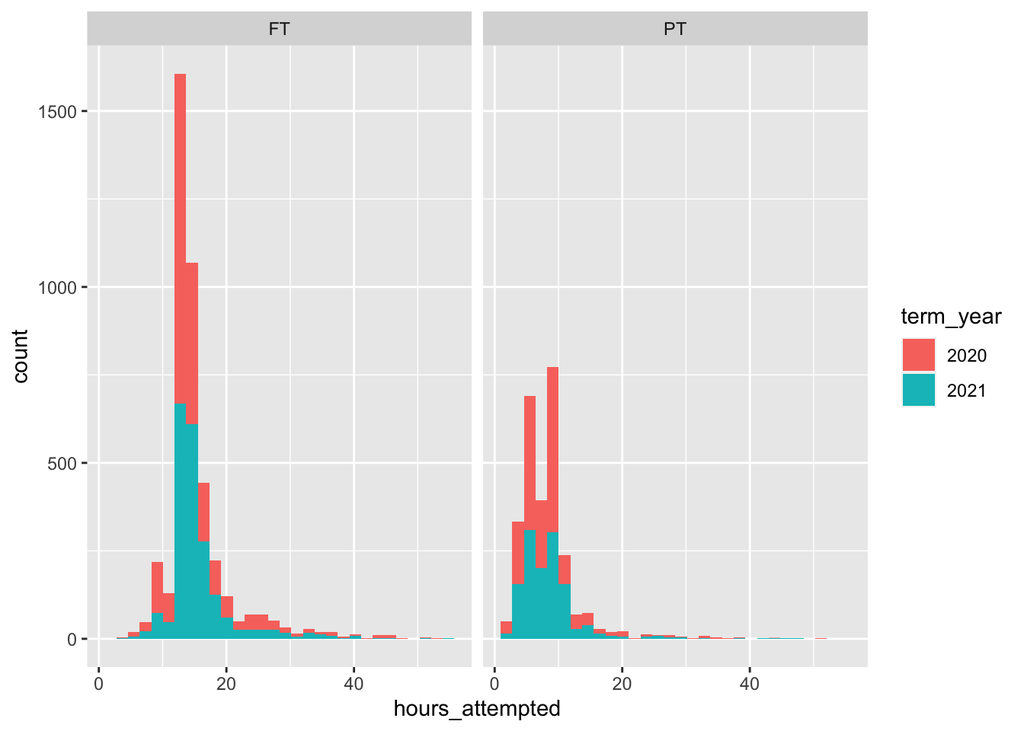

```r
p <- ggplot(df_creditsDegrees, aes(x = hours_attempted))+ geom_histogram(aes(fill = term_year))
p1<- p + facet_wrap(~full_part)

p1
```

Boxplots of hours_attempted by year

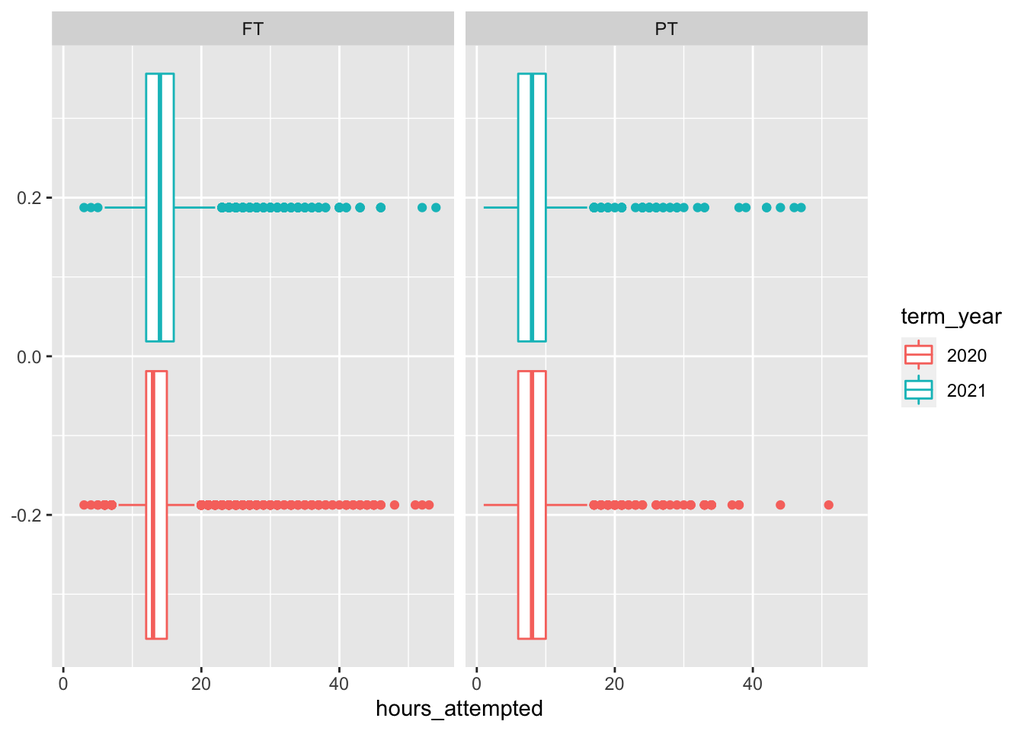

```r
p11 = ggplot(df_creditsDegrees, aes(hours_attempted))
p11 + geom_boxplot(aes(colour = term_year)) +
       facet_wrap(~full_part)
```

Density plot of hours_attempted by year

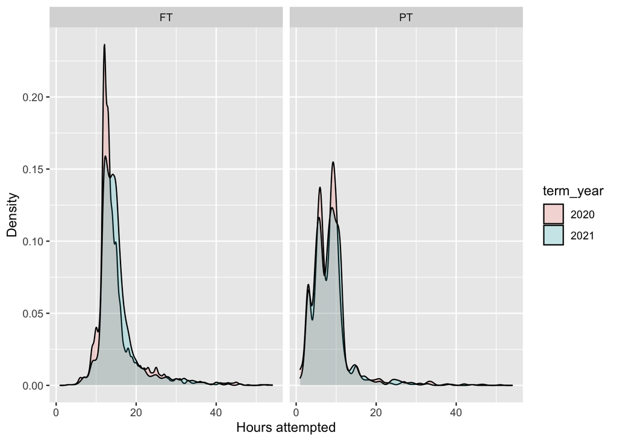

```r
ggplot(df_creditsDegrees, aes(hours_attempted, fill = term_year)) + geom_density(alpha = 0.2) +
  facet_wrap(~full_part)+
  xlab("Hours attempted") +
  ylab( "Density")
```

## 5.2 Question 2 : Hours Earned

Histogram of hours_earned by year

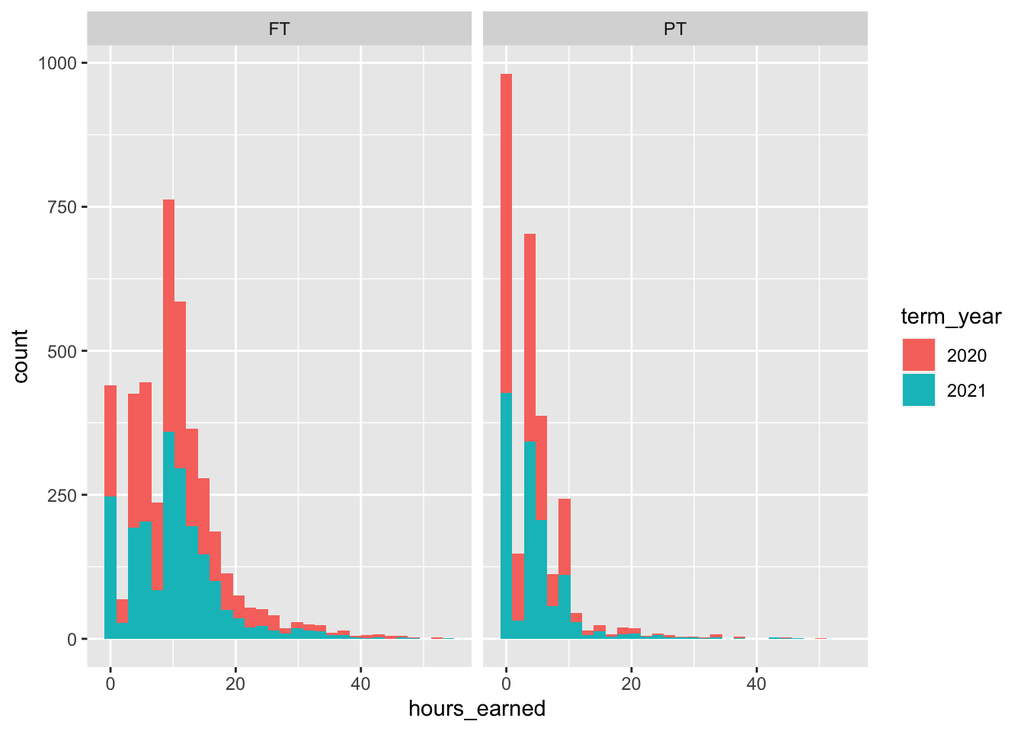

```r
p <- ggplot(df_creditsDegrees, aes(x = hours_earned))+ geom_histogram(aes(fill = term_year))
p1<- p + facet_wrap(~full_part)

p1
```

Boxplots of hours_earned by year

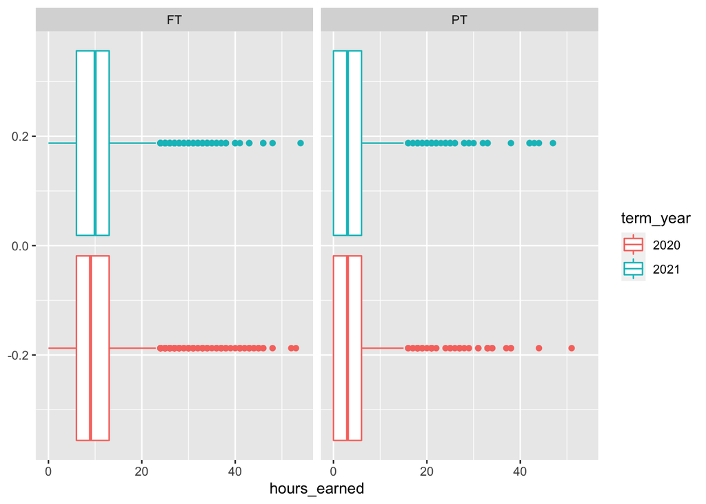

```r
p11 = ggplot(df_creditsDegrees, aes(hours_earned))
p11 + geom_boxplot(aes(colour = term_year)) +
       facet_wrap(~full_part)
```

Density plot of hours_earned by year

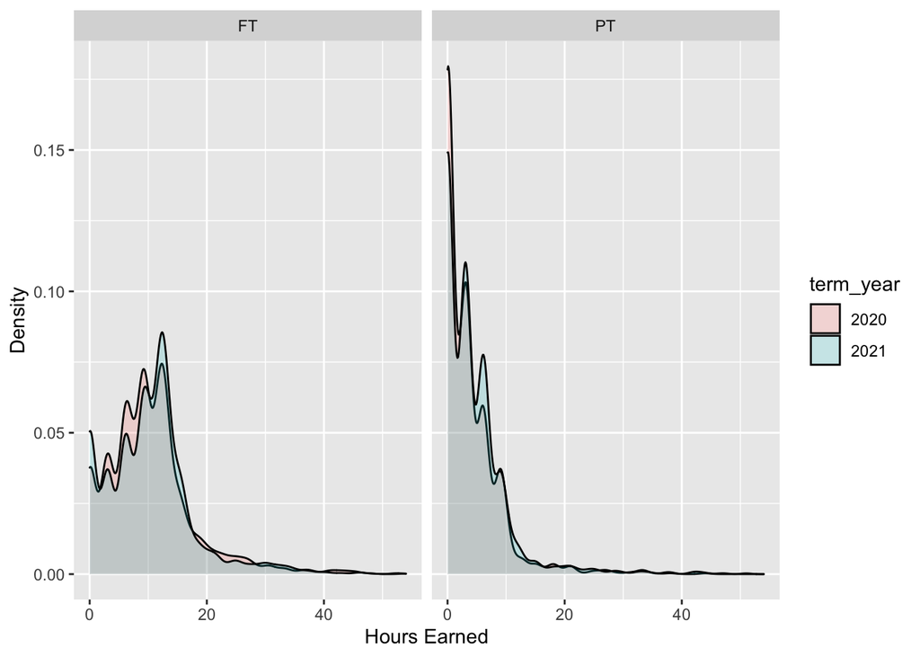

```r
ggplot(df_credits, aes(hours_earned, fill = term_year)) + geom_density(alpha = 0.2) +
  facet_wrap(~full_part)+
  xlab("Hours Earned") +
  ylab( "Density")
```

## 5.3 Question 3: Hours Pass Rate

Histogram of Hours Pass Rate by year

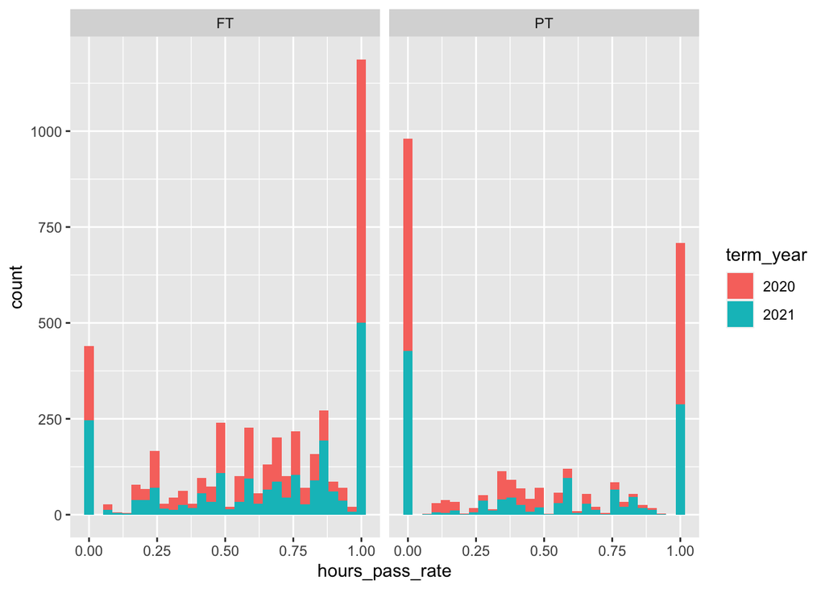

```r
p <- ggplot(df_creditsDegrees, aes(x = hours_pass_rate))+ geom_histogram(aes(fill = term_year))
p1<- p + facet_wrap(~full_part)

p1
```

Boxplots of Hours Pass Rate by year

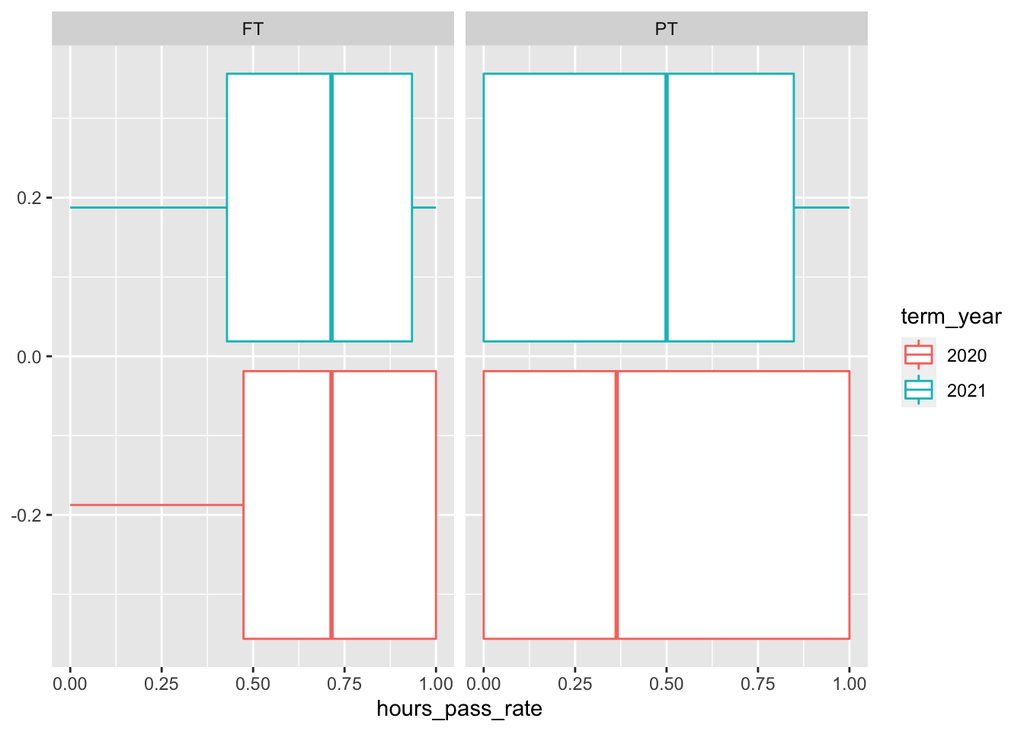

```r
p7 = ggplot(df_creditsDegrees, aes(hours_pass_rate))
p7 + geom_boxplot(aes(colour = term_year)) +
    facet_wrap(~full_part)
```

Density plot of Hours Pass Rate by year

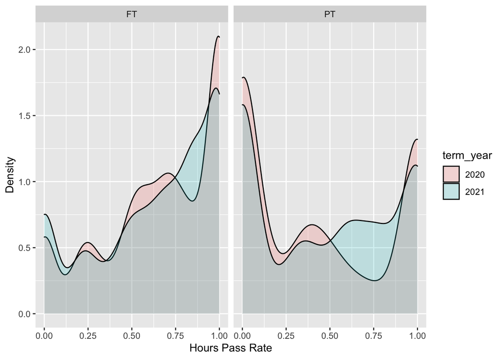

```r
ggplot(df_creditsDegrees, aes(hours_pass_rate, fill = term_year)) + geom_density(alpha = 0.2) +
  facet_wrap(~full_part)+
  xlab("Hours Pass Rate") +
  ylab( "Density")
```